# Introduction

Paul Little

2022-05-08

# Overview

Assuming all software dependencies and **ROKET** installation are installed, we can begin.

```r
# Load libraries
req_packs = c("devtools","smarter","ggplot2","reshape2",
  "survival","ggdendro","MiRKAT","ROKET")
for(pack in req_packs){
  library(package = pack,character.only = TRUE)
}
# List package's exported functions
ls("package:ROKET")
```

```
#> [1] "kernTEST"     "kOT_sim_AGG"  "kOT_sim_make" "kOT_sim_OT"   "kOT_sim_REG"
#> [6] "run_myOT"     "run_myOTs"
```

```r
# Fix seed
set.seed(2)
```

# Distance Motivation

For $i = 1,\ldots,N$ and $g = 1,\ldots,G$, let

- $Z_{ig} = 1$ indicate the $i$th sample’s $g$th gene is mutated and $Z_{ig} = 0$ otherwise
- $\mathbf{Z}_i \equiv \left(Z_{i1},\ldots,Z_{iG}\right)^\text{T}$

We would like to calculate the distance between the $i$th and $j$th samples in terms of mutated genes $\mathbf{Z}_i$ and $\mathbf{Z}_j$, denoted by $d\left(\mathbf{Z}_i,\mathbf{Z}_j\right)$.

## Optimal Transport

### Background papers

Several optimal transport (OT) references to get familiarized with the framework, objective functions, updating equations, entropic regularizations, types of OT are provided:

- Cuturi (2013), [paper](https://arxiv.org/pdf/1306.0895.pdf)
- Zhang, Zhong, and Ma (2020), [paper](https://arxiv.org/pdf/2008.02995.pdf)
- Nath and Jawanpuria (2020), [paper](https://arxiv.org/pdf/2002.03179.pdf)
- Fatras et al. (2021), [paper](http://proceedings.mlr.press/v139/fatras21a/fatras21a.pdf)
- Chapel et al. (2021), [paper](https://arxiv.org/pdf/2106.04145.pdf)

### Basic Idea

For the $i$th and $j$th samples, let

- $\mathbf{P}^{(ij)} =$ an unknown $G$ by $G$ transport matrix to be estimated
- $P_{gh}^{(ij)} =$ the value of the $g$th row and $h$th column of $\mathbf{P}$, denotes the mass transported between the $g$th gene of the $i$th sample and the $h$th gene of the $j$th sample
- $\mathbf{W} =$ a known $G$ by $G$ cost matrix, independent of samples
- $W_{gh} =$ the value of the $g$th row and $h$th column of $\mathbf{W}$, denotes the cost to transport one unit of mass between the $g$th gene and $h$th gene
- The space of transport matrices $\mathbf{P}^{(ij)}$ to search over is governed through the penalized divergence between $\mathbf{Z}_i$ and the row sums of $\mathbf{P}^{(ij)}$ as well as between $\mathbf{Z}_j$ and the column sums of $\mathbf{P}^{(ij)}$
- $\widehat{\mathbf{P}^{(ij)}} = \text{argmin}_{\mathbf{P}^{(ij)}} \left(\sum_g \sum_h P_{gh}^{(ij)} W_{gh}\right)$, the optimal transport matrix
- $d\left(\mathbf{Z}_i,\mathbf{Z}_j\right) = \sum_g \sum_h \widehat{P_{gh}^{(ij)}} W_{gh}$

### Balanced OT

If the mass of the two vectors **are equal** or normalized such that $\sum_g Z_{ig} = \sum_g Z_{jg}$, we could use balanced optimal transport.

### Unbalanced OT

If the mass of the two vectors **are not equal**, $\sum_g Z_{ig} \neq \sum_g Z_{jg}$, we could use unbalanced optimal transport with penalty parameters.

## Simulated Example

The code below will simulate samples and mutated genes. We welcome the reader to manipulate the following input arguments:

- `NN` for sample size,
- `PP` for number of pathways,
- `GG` for number of genes, and
- `bnd_same` the lower bound gene similarity for genes sharing the same pathway and `1 - bnd_same`, an upper bound on gene similarity for genes not sharing the same pathway

Ideally, `PP` should be much less than `GG` to allow multiple genes to be allocated to each pathway.

```r
# number of samples
NN = 30
NN_nms = sprintf("S%s",seq(NN))

# number of pathways
PP = 4
PP_nms = sprintf("P%s",seq(PP))

# number of genes
GG = 30
GG_nms = sprintf("G%s",seq(GG))

# bound for gene similarity of two genes on same or different pathway
bnd_same = 0.75

# Gene and pathway relationship
GP = smart_df(PATH = sample(seq(PP),GG,replace = TRUE),
  GENE = seq(GG))
table(GP$PATH)
```

```
#>
#> 1 2 3 4
#> 9 6 7 8
```

```r
# gene-gene similarity matrix
GS = matrix(NA,GG,GG)
dimnames(GS) = list(GG_nms,GG_nms)
diag(GS) = 1

tmp_mat = t(combn(seq(GG),2))

for(ii in seq(nrow(tmp_mat))){

  G1 = tmp_mat[ii,1]
  G2 = tmp_mat[ii,2]
  same = GP$PATH[GP$GENE == G1] == GP$PATH[GP$GENE == G2]

  if( same )
    GS[G1,G2] = runif(1,bnd_same,1)
  else
    GS[G1,G2] = runif(1,0,1 - bnd_same)

}
GS[lower.tri(GS)] = t(GS)[lower.tri(GS)]
# round(GS,3)
```

### Gene-Gene Similarity

Let’s take a look at the gene similarity matrix.

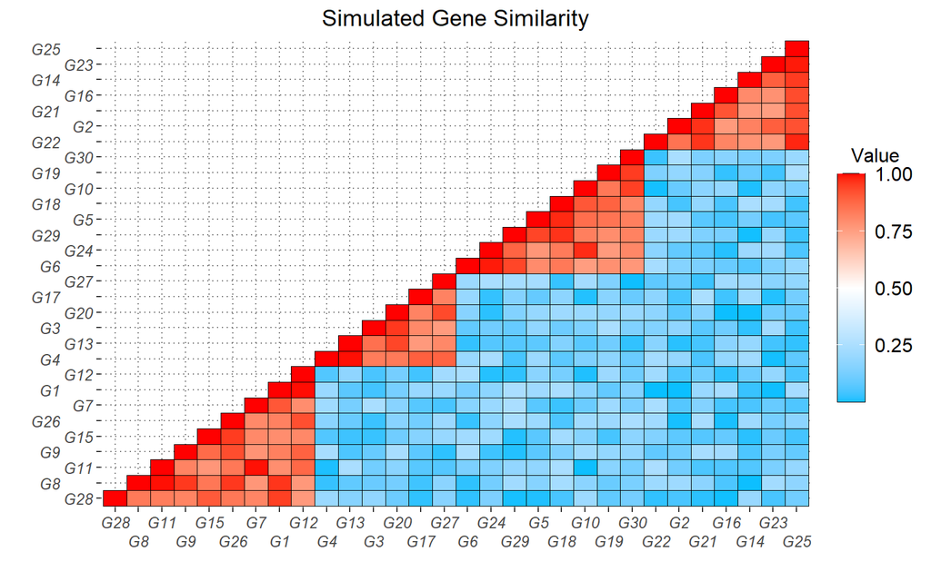

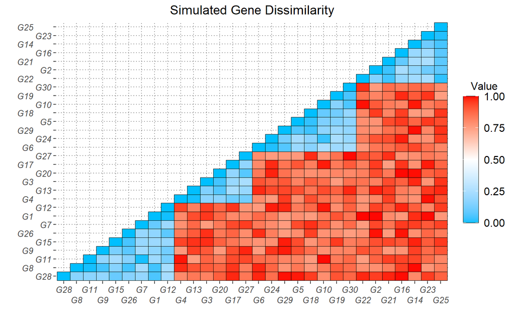

The function `show_tile()` is inherent to this vignette and not part of the **ROKET** package.

### Simulate mutated gene statuses

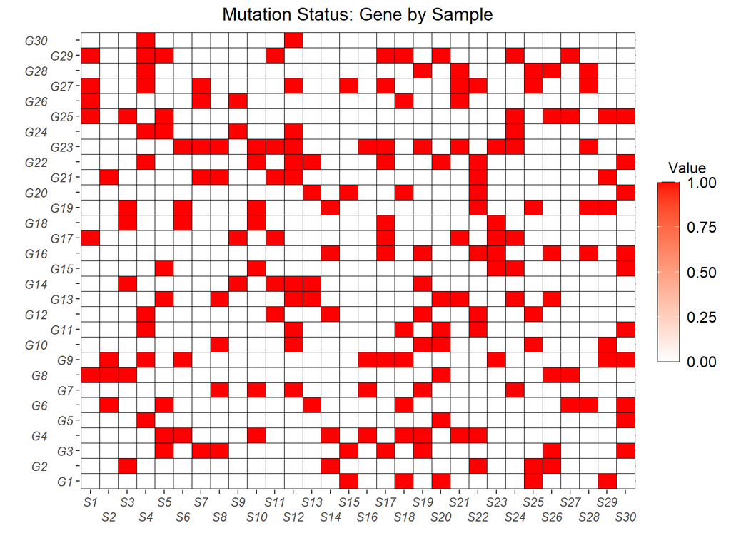

```r
# Mutated gene statuses
prob_mut = 0.2
prob_muts = c(1 - prob_mut,prob_mut)
while(TRUE){
  ZZ = matrix(sample(c(0,1),NN*GG,replace = TRUE,prob = prob_muts),NN,GG)

  # Ensure each sample has at least one mutated gene
  if( min(rowSums(ZZ)) > 0 ) break
}
dimnames(ZZ) = list(NN_nms,GG_nms)

show_tile(MAT = ZZ,
  LABEL = "Mutation Status: Gene by Sample",
  TYPE = "MUT",DIGITS = 0)
```

```r
# Store all distances
DD = array(data = NA,dim = c(NN,NN,5))
dimnames(DD)[1:2] = list(NN_nms,NN_nms)
dimnames(DD)[[3]] = c("EUC","OT_Balanced",sprintf("OT_LAM%s",c(0.5,1.0,5.0)))
```

We can look at the distribution of gene mutation frequencies.

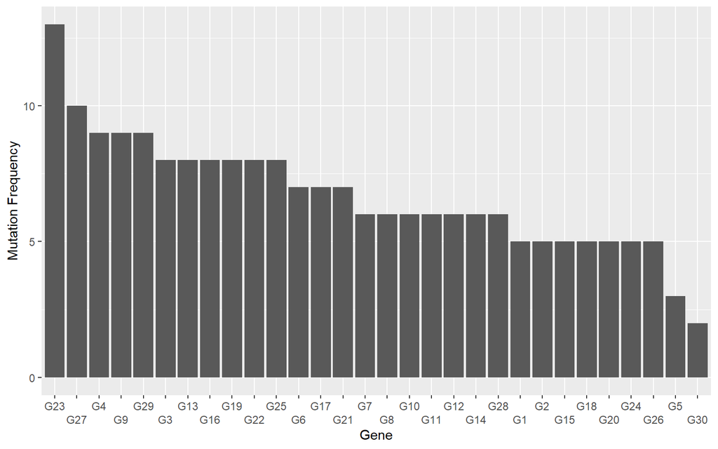

```r
freq = colSums(ZZ); # freq
dat = smart_df(GENE = names(freq),FREQ = as.integer(freq))
dat$GENE = factor(dat$GENE,levels = names(sort(freq,decreasing = TRUE)))
# dat

ggplot(data = dat,mapping = aes(x = GENE,y = FREQ)) +
  geom_bar(stat = "identity") +
  xlab("Gene") + ylab("Mutation Frequency") +
  scale_x_discrete(guide = guide_axis(n.dodge = 2))
```

### Euclidean distance

We can calculate the Euclidean distance, which does not incorporate relationships between pairs of genes.

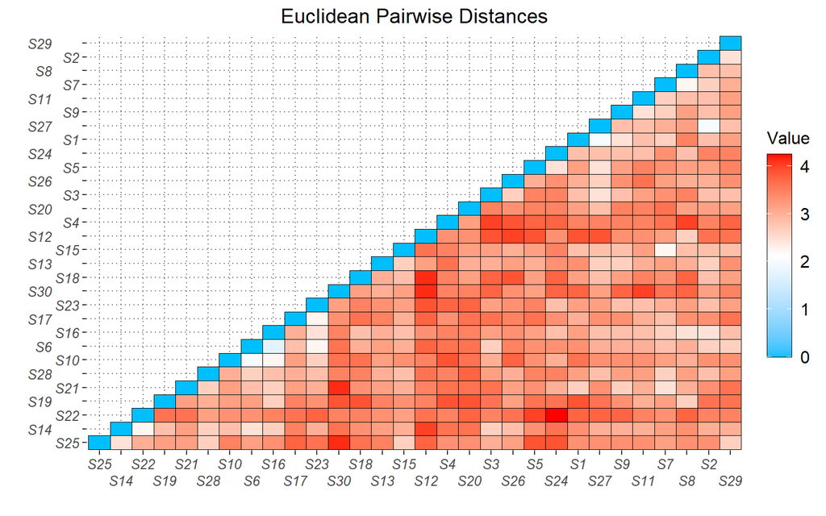

```r
DD[,,"EUC"] = as.matrix(dist(ZZ,diag = TRUE,upper = TRUE))

hout = hclust(as.dist(DD[,,"EUC"]))
ord = hout$labels[hout$order]
show_tile(MAT = DD[,,"EUC"][ord,ord],
  LABEL = "Euclidean Pairwise Distances",
  TYPE = "DIST",DIGITS = 2)
```

### OT distance

#### Code between two samples

To demonstrate **ROKET**’s functionality, the code below will run balanced OT (pre-normalizing input vectors) between two samples. Regardless of the values specified by `LAMBDA1` and `LAMBDA2` arguments, we need to set `balance = TRUE`. The OT cost matrix argument corresponds to `1 - GS`, one minus the gene similarity matrix.

```r
# Pick two samples
ii = 1
jj = 2
ZZ[c(ii,jj),colSums(ZZ[c(ii,jj),]) > 0]
```

```
#>    G6 G8 G9 G17 G21 G25 G26 G27 G29
#> S1  0  1  0   1   0   1   1   1   1
#> S2  1  1  1   0   1   0   0   0   0
```

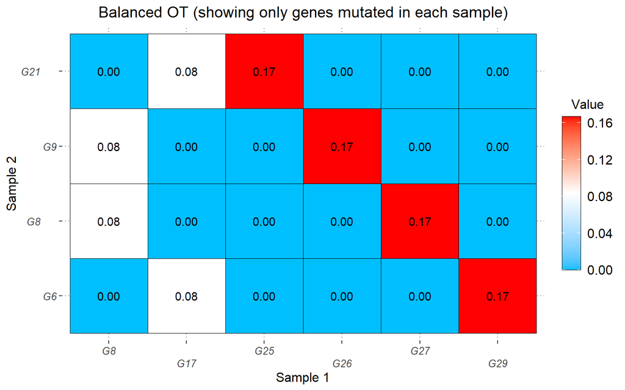

```r
outOT = run_myOT(XX = ZZ[ii,],YY = ZZ[jj,],
  COST = 1 - GS,EPS = 1e-3,LAMBDA1 = 1,
  LAMBDA2 = 1,balance = TRUE,verbose = FALSE)
# str(outOT)

# Optimal transport matrix
tmpOT = outOT$OT
tmpOT = tmpOT[rowSums(tmpOT) > 0,colSums(tmpOT) > 0]
show_tile(MAT = tmpOT,LABEL = "Balanced OT (showing only genes mutated in each sample)",
  TYPE = "DIST",LABx = sprintf("Sample %s",ii),
  LABy = sprintf("Sample %s",jj),
  DIGITS = 2)
```

```r
# Pairwise distance
outOT$DIST
```

```
#> [1] 0.3069897
```

Let’s try again but with unbalanced OT and $\lambda = 0.5$. We need to set `balance = FALSE` and specify `LAMBDA1 = 0.5` and `LAMBDA2 = 0.5`.

```r
ZZ[c(ii,jj),colSums(ZZ[c(ii,jj),]) > 0]
```

```
#>    G6 G8 G9 G17 G21 G25 G26 G27 G29
#> S1  0  1  0   1   0   1   1   1   1
#> S2  1  1  1   0   1   0   0   0   0
```

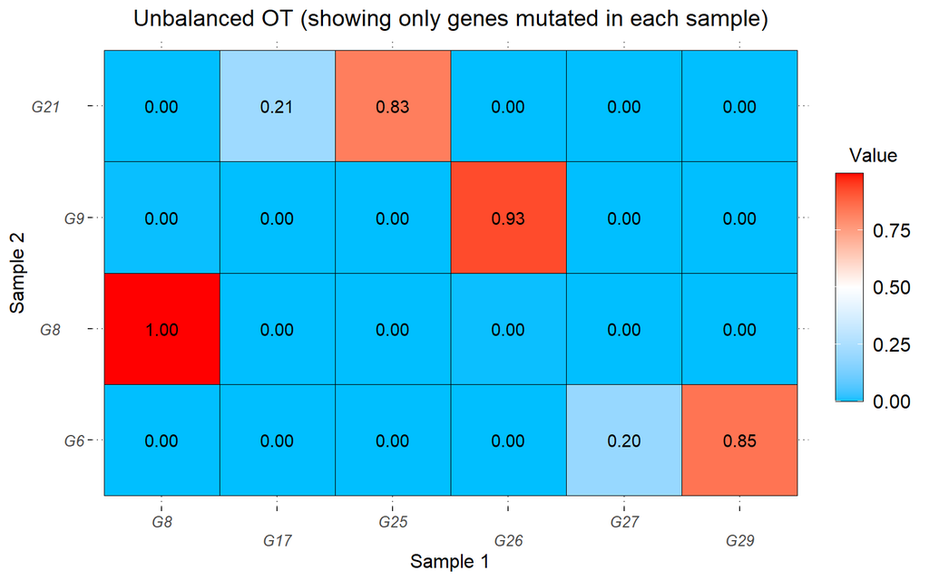

```r
LAM = 0.5
outOT = run_myOT(XX = ZZ[ii,],YY = ZZ[jj,],
  COST = 1 - GS,EPS = 1e-3,LAMBDA1 = LAM,
  LAMBDA2 = LAM,balance = FALSE,verbose = FALSE)
# str(outOT)

# Optimal transport matrix
tmpOT = outOT$OT
tmpOT = tmpOT[rowSums(tmpOT) > 0,colSums(tmpOT) > 0]
show_tile(MAT = tmpOT,
  LABEL = "Unbalanced OT (showing only genes mutated in each sample)",TYPE = "DIST",
  LABx = sprintf("Sample %s",ii),
  LABy = sprintf("Sample %s",jj),
  DIGITS = 2)
```

```r
# Pairwise distance
outOT$DIST
```

```
#> [1] 0.5026334
```

#### Code between all sample pairs

**ROKET** can run optimal transport calculations across all $N$ choose 2 samples. Below is code to run balanced OT.

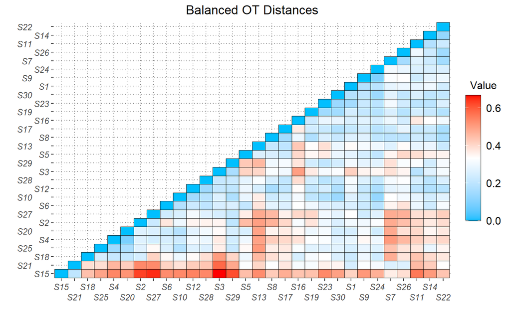

```r
outOTs = run_myOTs(ZZ = t(ZZ),COST = 1 - GS,
  EPS = 1e-3,balance = TRUE,LAMBDA1 = 1,
  LAMBDA2 = 1,conv = 1e-5,max_iter = 3e3,
  ncores = 1,verbose = FALSE)

hout = hclust(as.dist(outOTs))
ord = hout$labels[hout$order]
show_tile(MAT = outOTs[ord,ord],
  LABEL = "Balanced OT Distances",
  TYPE = "DIST",DIGITS = 1)
```

```r
LAMs = c(0,0.5,1.0,5.0)

for(LAM in LAMs){
  # LAM = LAMs[2]

  BAL = ifelse(LAM == 0,TRUE,FALSE)
  LAM2 = ifelse(BAL,1,LAM)

  outOTs = run_myOTs(ZZ = t(ZZ),COST = 1 - GS,
    EPS = 1e-3,balance = BAL,LAMBDA1 = LAM2,
    LAMBDA2 = LAM2,conv = 1e-5,max_iter = 3e3,
    ncores = 1,verbose = FALSE)

  hout = hclust(as.dist(outOTs))
  ord = hout$labels[hout$order]

  LABEL = ifelse(BAL,"OT Distances (Balanced)",
    sprintf("OT Distances (Lambda = %s)",LAM))
  LABEL2 = ifelse(BAL,"OT_Balanced",sprintf("OT_LAM%s",LAM))

  gg = show_tile(MAT = outOTs[ord,ord],
    LABEL = LABEL,TYPE = "DIST",DIGITS = 2)
  print(gg)

  DD[,,LABEL2] = outOTs
  rm(outOTs)
}
```

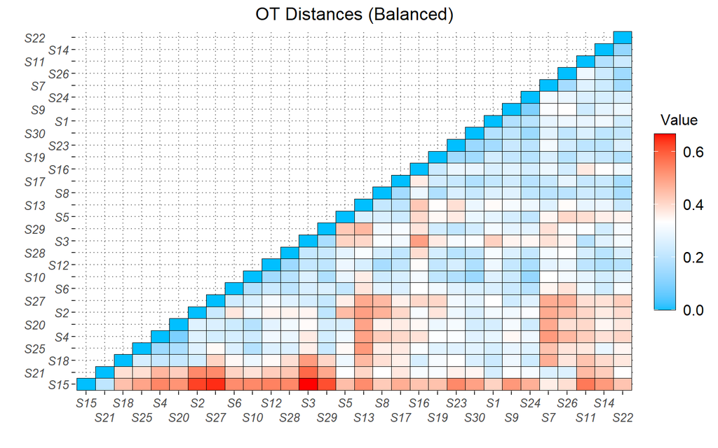

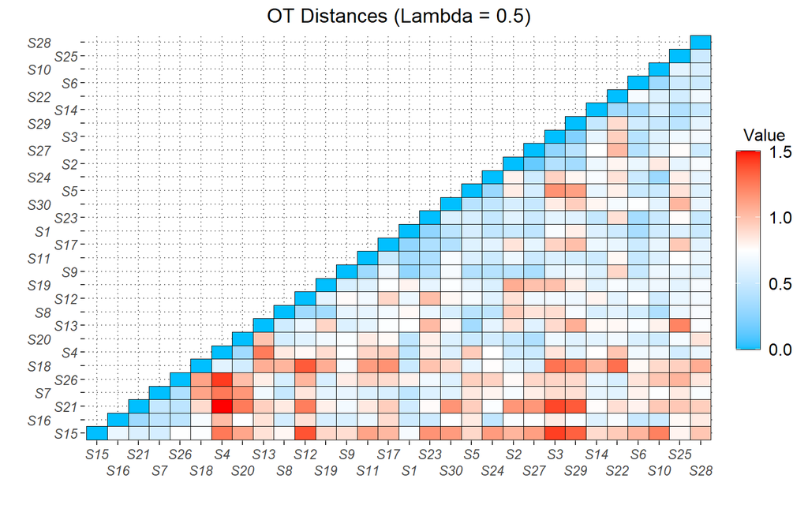

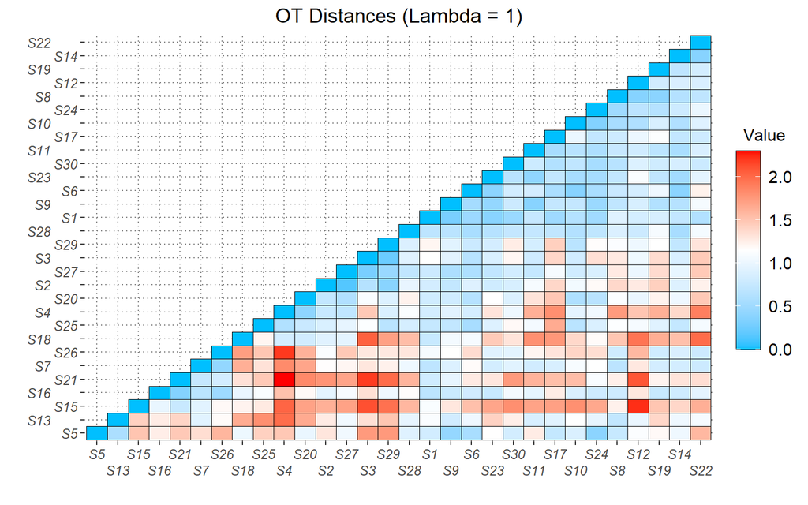

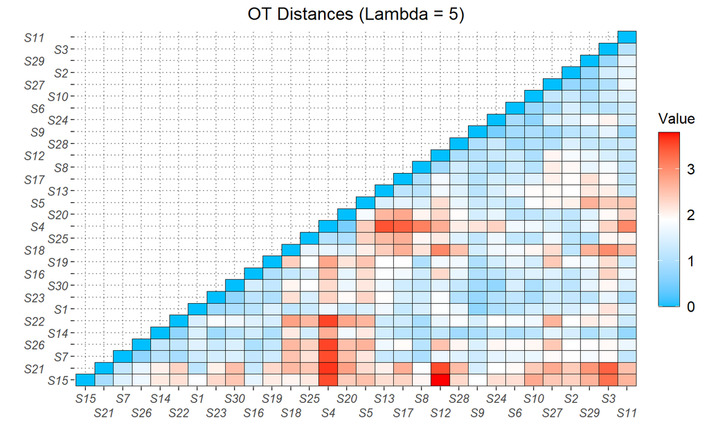

### Dendrograms

We can see that Euclidean distance calculations on gene mutation statuses alone does not lead to strong evidence of sample clusters. However optimal transport-based distance calculations with integrated gene-gene similarities provide stronger evidence of sample clusters.

```r
nms = dimnames(DD)[[3]]; nms
```

```
#> [1] "EUC"         "OT_Balanced" "OT_LAM0.5"   "OT_LAM1"     "OT_LAM5"
```

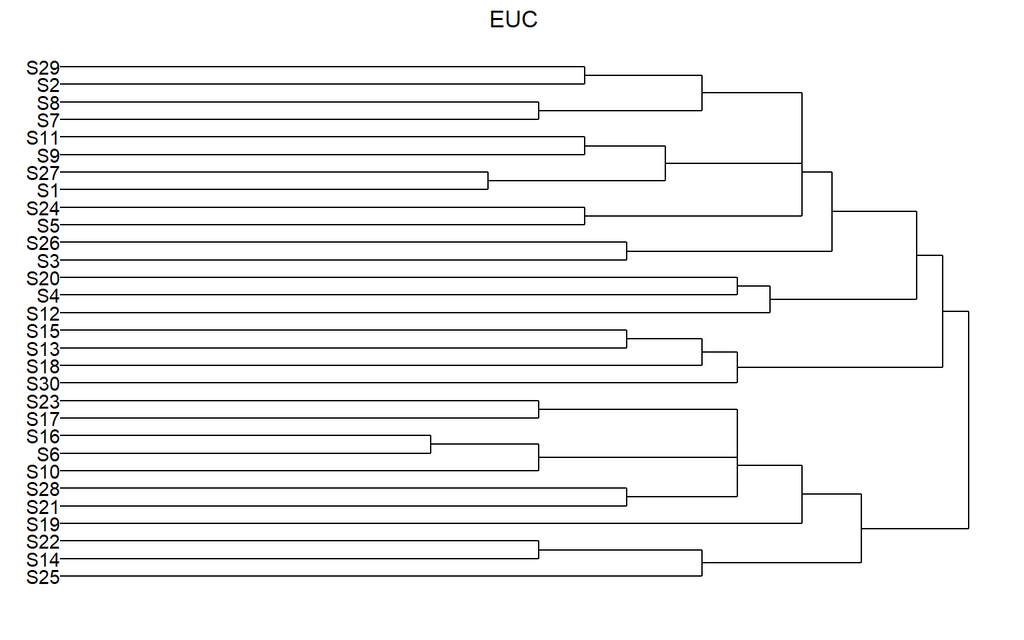

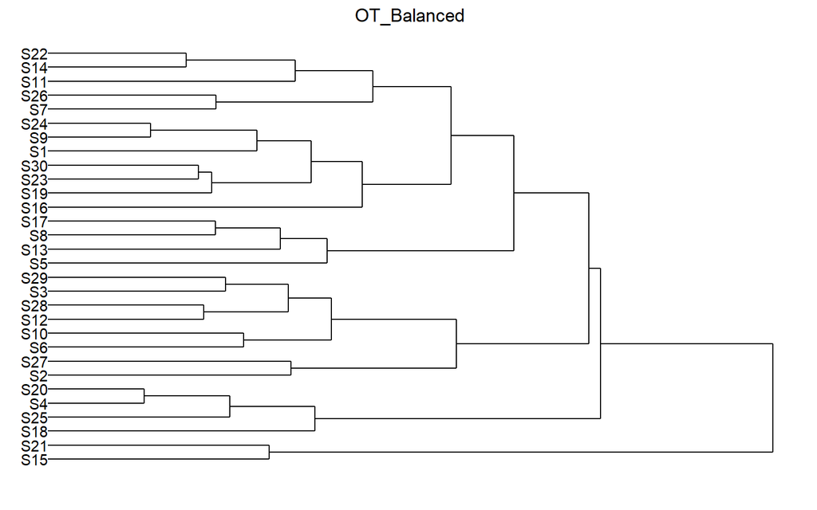

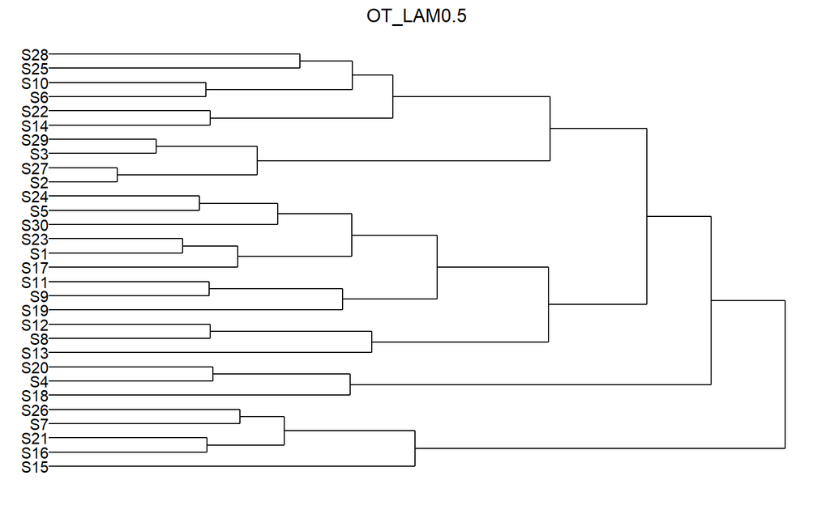

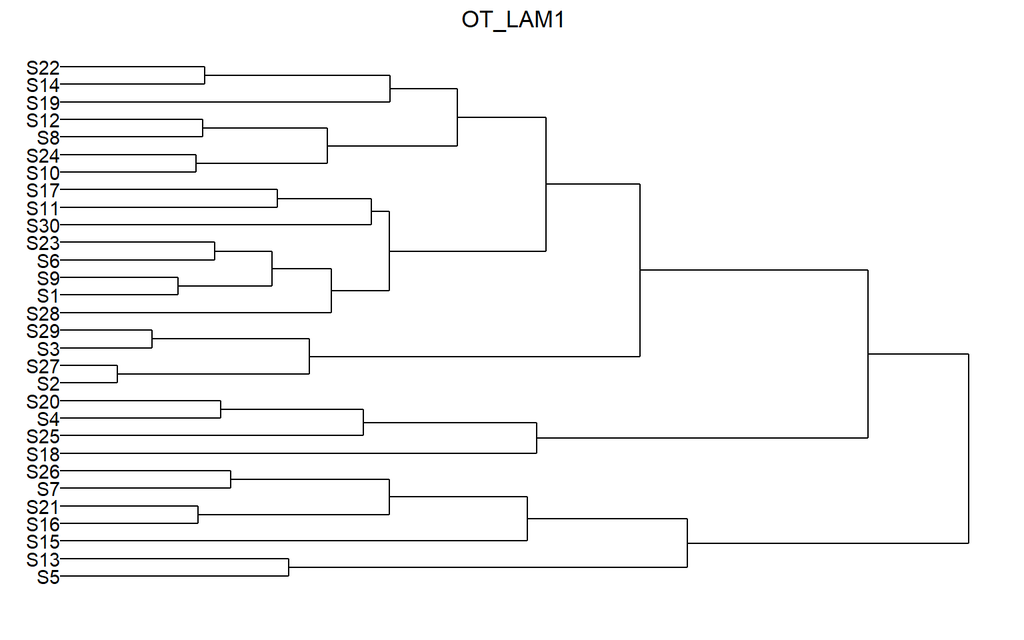

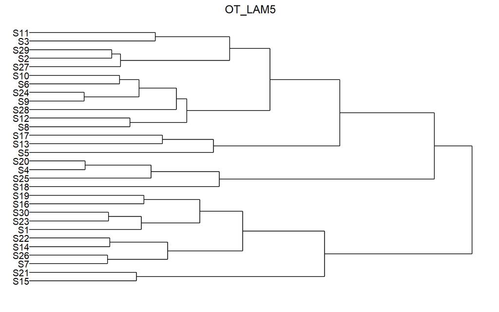

```r
for(nm in nms){
  # nm = nms[2]

  hout = hclust(as.dist(DD[,,nm]))
  hdend = as.dendrogram(hout)
  dend_data = dendro_data(hdend,type = "rectangle")
  gg = ggplot(dend_data$segments) +
    geom_segment(aes(x = x,y = y,xend = xend,yend = yend)) +
    ggtitle(nm) + xlab("") + ylab("") +
    geom_text(data = dend_data$labels,
      mapping = aes(x,y,label = label),vjust = 0.5,hjust = 1) +
    theme_dendro() + coord_flip() +
    theme(plot.title = element_text(hjust = 0.5))
  print(gg)
  rm(hout,hdend,dend_data,gg)
}
```

# Kernel Regression and Association

The next step is to transform distance matrices into centered kernel matrices to perform hypothesis testing on our constructed kernels.

## Models

For a binary or continuous outcome, $Y_i$, fitted with a generalized linear model, we have

$$g\left(E\left[Y_i \middle| \mathbf{X}_i,\mathbf{Z}_i\right]\right) = \mathbf{X}_i^\text{T}\mathbf{\beta} + f(\mathbf{Z}_i) = \mathbf{X}_i^\text{T}\mathbf{\beta} + \mathbf{K}_i^\text{T}\mathbf{\alpha}$$

and for Cox proportional hazards for survival outcomes, we have

$$h(t;\mathbf{X}_i,\mathbf{Z}_i) = h_0(t) \exp\left\{\mathbf{X}_i^\text{T}\mathbf{\beta} + f(\mathbf{Z}_i)\right\} = h_0(t) \exp\left\{\mathbf{X}_i^\text{T}\mathbf{\beta} + \mathbf{K}_i^\text{T}\mathbf{\alpha}\right\}$$

where

- $h_0(t)$ is the baseline hazards function,
- $g\left(\cdot\right)$ is a known link function,
- $f\left(\cdot\right)$ is assumed to be generated by a positive semi-definite function $K\left(\cdot,\cdot\right)$ such that $f(\cdot)$ lies in the reproducing kernel Hilbert space $\mathcal{H}_K$,
- $\mathbf{X}_i$ denotes $p$ baseline covariates to adjust for,
- $\mathbf{K}_i = (K_{i1},\ldots,K_{iN})^\text{T}$, the $i$th column of kernel matrix $\mathbf{K}$, and
- $\mathbf{\alpha} = (\alpha_1,\ldots,\alpha_N)^\text{T}$.

## Distance to Kernel

The matrix $\mathbf{K}$ is constructed from the distance matrix (Euclidean or optimal transport), $\mathbf{D}$, by double centering the rows and columns of $\mathbf{D}$ with the formula

$$\tilde{\mathbf{K}} = -\frac{1}{2} \left(\mathbf{I}_N - \mathbf{J}_N \mathbf{J}_N^\text{T}\right) \mathbf{D}^2 \left(\mathbf{I}_N - \mathbf{J}_N \mathbf{J}_N^\text{T}\right)$$

where

- $\mathbf{D}^2$ is the element-wise squared distance matrix,
- $\mathbf{I}_N$ is an $N \times N$ identity matrix, and
- $\mathbf{J}_N$ is a column vector of $N$ ones.

Since $\tilde{\mathbf{K}}$ is not guaranteed to be positive semi-definite, we perform spectral decomposition and replace negative eigenvalues with zero and re-calculate the kernel to arrive at $\mathbf{K}$.

For a single candidate distance matrix, transform the distance matrix to a kernel matrix and convert the object into a list, denoted by the object `KK`, code is provided below from the R package, [**MiRKAT**](https://cran.r-project.org/web/packages/MiRKAT/index.html) (Zhao et al. 2015; Plantinga et al. 2017).

```r
# For example, with Euclidean distance
KK = MiRKAT::D2K(D = DD[,,"EUC"])
KK = list(EUC = KK)
```

If there are multiple distance matrices, in our case, contained in an array `DD`, store them into a list of kernel matrices `KK`. Example code is below.

```r
KK = list()

for(nm in dimnames(DD)[[3]]){
  KK[[nm]] = MiRKAT::D2K(D = DD[,,nm])
}
```

## Hypothesis Testing

The user needs to pre-specify and fit the null model,

$$H_0: \mathbf{\alpha} = 0,$$

of baseline covariates, $\mathbf{X}_i$, to one of the three outcome models to obtain continuous, logistic, or martingale residuals (`RESI`). Some example code is provided below.

```r
# Continuous
out_LM = lm(Y ~ .,data = data.frame(X))
RESI = residuals(out_LM)

# Logistic
out_LOG = glm(Y ~ .,data = data.frame(X),family = "binomial")
RESI = residuals(out_LOG)

# Survival
out_CX = coxph(Surv(TIME,CENS) ~ .,data = data.frame(X))
RESI = residuals(out_CX)
```

With one or multiple candidate kernels, **ROKET** will take

- a R array of kernel matrices (`aKK`) (defined below),
- the residual vector (`RESI`), and
- user-supplied number of permutations (`nPERMS`)

to calculate individual kernel p-values as well as omnibus tests. An omnibus test assesses the significance of the minimum p-value kernel among kernels considered. The function `kernTEST` requires `names(RESI)` and dimension names per object as well as row/column names per kernel within `aKK` are named for sample order consistency. Sample code is provided below. Setting `verbose = TRUE` allows the user to track the permutation’s progress, especially when requesting hundreds of thousands of permutations.

```r
nPERMS = 1e5
nKK = length(KK)

# Array of kernels
aKK = array(data = NA,dim = dim(DD),
  dimnames = dimnames(DD))
for(nm in dimnames(DD)[[3]]){
  aKK[,,nm] = KK[[nm]]
}

# Create OMNI matrix
OMNI = matrix(0,nrow = 2,ncol = dim(aKK)[3],
  dimnames = list(c("EUC","OT"),dimnames(aKK)[[3]]))
OMNI["EUC","EUC"] = 1
OMNI["OT",grepl("^OT",colnames(OMNI))] = 1
OMNI

# Hypothesis Testing
ROKET::kernTEST(RESI = RESI,
  KK = aKK,
  OMNI = OMNI,
  nPERMS = nPERMS,
  ncores = 1)
```

The final output contains individual kernel p-values and the omnibus p-value.

Have fun with utilizing kernel regression and optimal transport frameworks with **ROKET**!

# References

Chapel, Laetitia, Rémi Flamary, Haoran Wu, Cédric Févotte, and Gilles Gasso. 2021. “Unbalanced Optimal Transport Through Non-Negative Penalized Linear Regression.” *arXiv Preprint arXiv:2106.04145*.

Cuturi, Marco. 2013. “Sinkhorn Distances: Lightspeed Computation of Optimal Transport.” *Advances in Neural Information Processing Systems* 26: 2292–2300.

Fatras, Kilian, Thibault Séjourné, Rémi Flamary, and Nicolas Courty. 2021. “Unbalanced Minibatch Optimal Transport; Applications to Domain Adaptation.” In *International Conference on Machine Learning*, 3186–97. PMLR.

Nath, J Saketha, and Pratik Jawanpuria. 2020. “Statistical Optimal Transport Posed as Learning Kernel Embedding.” *arXiv Preprint arXiv:2002.03179*.

Plantinga, Anna, Xiang Zhan, Ni Zhao, Jun Chen, Robert R Jenq, and Michael C Wu. 2017. “MiRKAT-s: A Community-Level Test of Association Between the Microbiota and Survival Times.” *Microbiome* 5 (1): 1–13.

Zhang, Jingyi, Wenxuan Zhong, and Ping Ma. 2020. “A Review on Modern Computational Optimal Transport Methods with Applications in Biomedical Research.” *arXiv Preprint arXiv:2008.02995*.

Zhao, Ni, Jun Chen, Ian M Carroll, Tamar Ringel-Kulka, Michael P Epstein, Hua Zhou, Jin J Zhou, Yehuda Ringel, Hongzhe Li, and Michael C Wu. 2015. “Testing in Microbiome-Profiling Studies with MiRKAT, the Microbiome Regression-Based Kernel Association Test.” *The American Journal of Human Genetics* 96 (5): 797–807.